# Analyzing personal activity monitoring data

Pavel Bukhtik

22/01/2017

## Loading and preprocessing the data

Download and load data into data frame “data”

```r
if(!file.exists("activity.csv")) {
        temp <- tempfile()
        download.file("https://d396qusza40orc.cloudfront.net/repdata%2Fdata%2Factivity.zip",temp)
        unzip(temp)
        unlink(temp)
}
data <- read.csv("activity.csv")
```

Sum steps by day, create histogram.

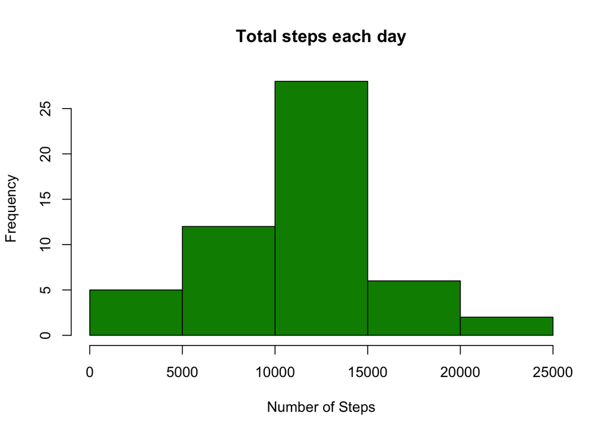

```r
stepsByDay <- aggregate(steps ~ date, data, sum)
hist(stepsByDay$steps, main = "Total steps each day", col="green4", xlab="Number of Steps")
```

Calculate mean and median.

```r
stepsMean <- mean(stepsByDay$steps)
stepsMedian <- median(stepsByDay$steps)
```

## What is the average daily activity pattern?

Calculate average steps for each interval for all days and plot the average number of steps per day by interval.

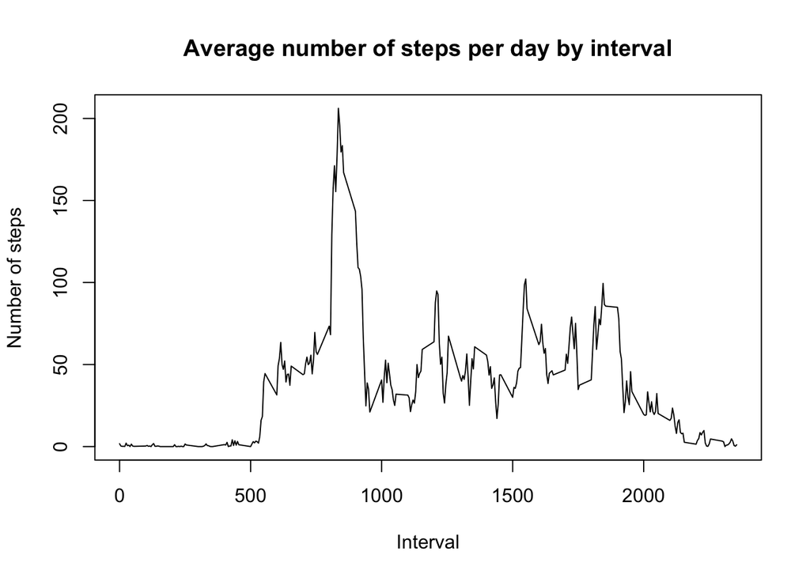

```r
stepsByInterval <- aggregate(steps ~ interval, data, mean)
plot(stepsByInterval$interval,stepsByInterval$steps, type="l", xlab="Interval", ylab="Number of steps",main="Average number of steps per day by interval")
```

Find interval with most average steps.

```r
maxInterval <- stepsByInterval[which.max(stepsByInterval$steps),1]
```

The 5-minute interval, on average across all the days in the data set, containing the maximum number of steps is 835

## Imputing missing values

Missing data needed to be imputed. Missing values were imputed by inserting the average for each interval.

```r
incomplete <- sum(!complete.cases(data))
imputedData <- transform(data, steps = ifelse(is.na(data$steps), stepsByInterval$steps[match(data$interval, stepsByInterval$interval)], data$steps))
imputedData[as.character(imputedData$date) == "2012-10-01", 1] <- 0
```

NAs for 10-01-2012 were assumed to be zeros to fit the rising trend of the data.

Recount total steps by day and create histogram.

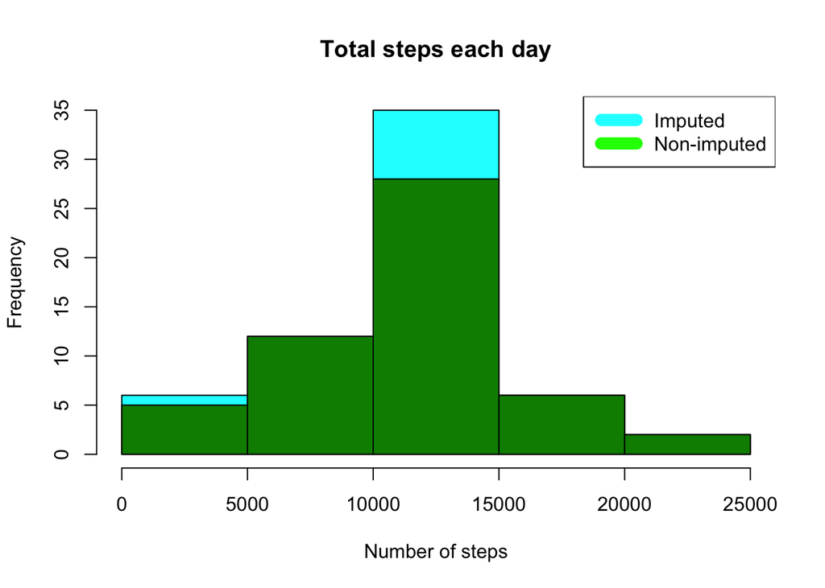

```r
stepsByDay2 <- aggregate(steps ~ date, imputedData, sum)
hist(stepsByDay2$steps, main = "Total steps each day", col="cyan", xlab="Number of steps")
hist(stepsByDay$steps, main = "Total steps each day", col="green4", xlab="Number of steps", add=TRUE)
legend("topright", c("Imputed", "Non-imputed"), col=c("cyan", "green"), lwd=10)
```

Calculate new mean and median for imputed data.

```r
stepsMean2 <- mean(stepsByDay2$steps)
stepsMedian2 <- median(stepsByDay2$steps)
```

Calculate difference between imputed and non-imputed data.

```r
meanDiff <- stepsMean2 - stepsMean
medianDiff <- stepsMedian2 - stepsMedian
```

Calculate total difference.

```r
totalDiff <- sum(stepsByDay2$steps) - sum(stepsByDay$steps)
```

The difference between the non-imputed mean and imputed mean is -176.4948964

The difference between the non-imputed median and imputed median is 1.1886792

## Are there differences in activity patterns between weekdays and weekends?

Create a plot to compare number of steps between the week and weekend.

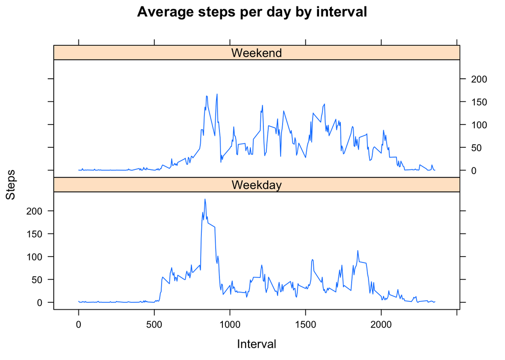

```r
weekdays <- c("Monday", "Tuesday", "Wednesday", "Thursday", "Friday")
imputedData$dow = as.factor(ifelse(is.element(weekdays(as.Date(imputedData$date)),weekdays), "Weekday", "Weekend"))

stepsByInterval2 <- aggregate(steps ~ interval + dow, imputedData, mean)

library(lattice)

xyplot(stepsByInterval2$steps ~ stepsByInterval2$interval|stepsByInterval2$dow, main="Average steps per day by interval",xlab="Interval", ylab="Steps",layout=c(1,2), type="l")
```